# DENDROplan Vignette

Zilu Zhou

10/25/2019

Abstract

# 1. Installation

Install all packages in the latest version of [R](https://www.r-project.org/).

```r
devtools::install_github("zhouzilu/DENDRO")
```

The reference dataset from Deng et al. (Deng et al. 2014) is pre-stored in the DENDRO package.

# 2. Questions & issues

If you have any questions or problems when using DENDROplan, please feel free to open a new issue [here](https://github.com/zhouzilu/DENDRO/issues). You can also email the maintainers of the package – the contact information is below.

- [Zilu Zhou](https://statistics.wharton.upenn.edu/profile/zhouzilu/) (zhouzilu at pennmedicine dot upenn dot edu)  
  Genomics and Computational Biology Graduate Group, UPenn
- [Nancy R. Zhang](https://statistics.wharton.upenn.edu/profile/nzh/) (nzh at wharton dot upenn dot edu)  
  Department of Statistics, UPenn

# 3. DENDROplan pipeline

## 3.1 Overall pipeline

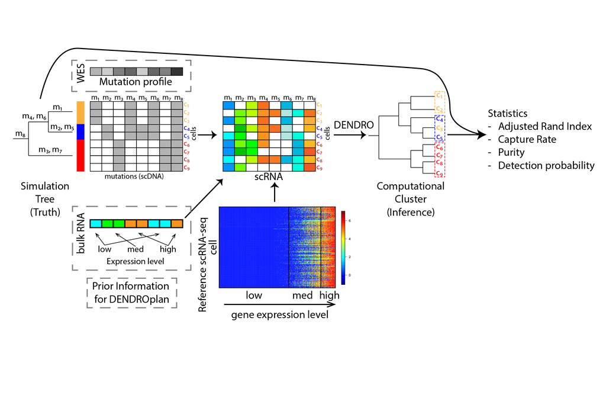

**Figure 2**. A flowchart outlining the procedures for DENDROplan.

## 3.2 Load reference

Our reference dataset is from Deng et al. (Deng et al. 2014) with great sequencing quality and depth. First, let’s load `DENDROplan_ref` and check the structure of the reference variable `ref`

```r
library(DENDRO)
data("DENDROplan_ref")
str(ref)
```

```
#> List of 3
#>  $ X1       : int [1:22958, 1:133] 0 0 0 0 0 0 0 0 0 0 ...
#>   ..- attr(*, "dimnames")=List of 2
#>   .. ..$ : NULL
#>   .. ..$ : chr [1:133] "GSM1112611_earlyblast_2-1_expression.txt" "GSM1112612_earlyblast_2-10_expression.txt" "GSM1112613_earlyblast_2-12_expression.txt" "GSM1112614_earlyblast_2-15_expression.txt" ...
#>  $ X2       : int [1:22958, 1:133] 0 0 0 0 0 0 0 0 0 0 ...
#>   ..- attr(*, "dimnames")=List of 2
#>   .. ..$ : NULL
#>   .. ..$ : chr [1:133] "GSM1112611_earlyblast_2-1_expression.txt" "GSM1112612_earlyblast_2-10_expression.txt" "GSM1112613_earlyblast_2-12_expression.txt" "GSM1112614_earlyblast_2-15_expression.txt" ...
#>  $ exp_level: chr [1:22958] "low" "low" "low" "low" ...
```

There are total 22958 potential mutation loci across 133 cells. As a result, when we simulate trees, the maximum number of cells is 133 and the maximum number of mutations is 22958.

## 3.3 Tree simulation

### 3.3.1 Tree type and parameters

The trees that DENDROplan is able to simulate show at Figure 3. The corresponding `k` and `subtype` value are also included.

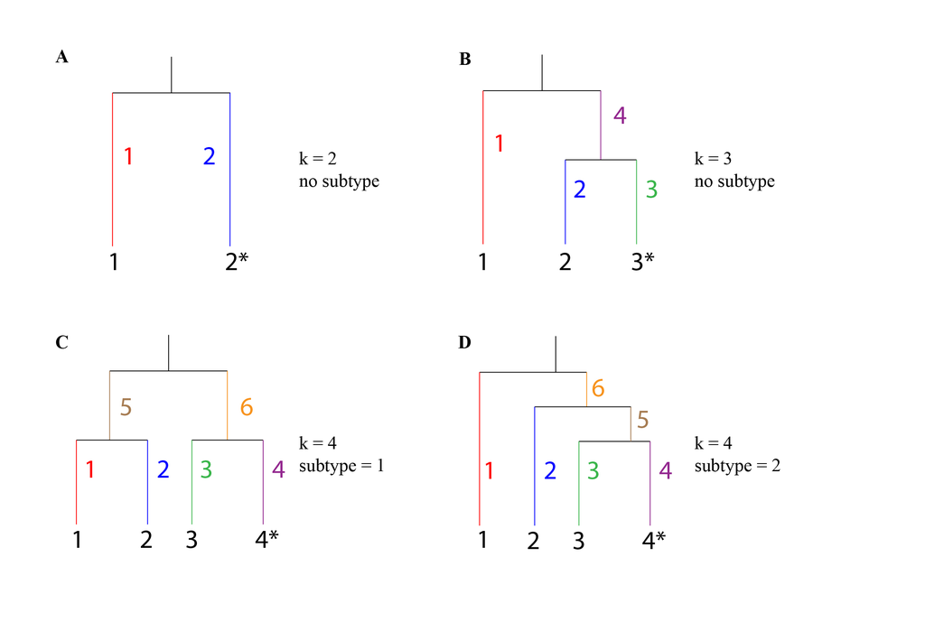

**Figure 3**. Example tree structure DENDRO can simulate with corresponding parameters.

Numbers on branches illustrate index of mutation probability variable `lprob`, and numbers at node illustrate index of cell proportion variable `kprob`. The interested clade is labeled by a *star*. Capture rate and purity are measured on that specific *star* cluster. `k` is the parameter indicating number of subclones. When `k=4`, the subclones can form two types of trees, differetiated by the `subtype` parameter.

### 3.3.2 Accuracy measurements

We measure DENDROplan results by four statistics, explained here:

- Adjusted Rand index: Adjusted Rand index is a measure of the similarity between two data clusterings after adjusted for the chance grouping of elements. For details, see [here](https://en.wikipedia.org/wiki/Rand_index)
- Capture rate: Capture rate is a measure of “false negative rate” of a specific *star* clade. Out of all the cells from the specific clade, how many of them is detected by the algorithm.
- Purity: Purity is a measure of “false positive rate” of a specific *star* clade. Out of all the cells in the “specific cluster” you detected, how many are actually from the true specific clade.
- Observation probability: This is only one single value, which measures the probability of observe all clades in our multipe simulation round.

## 3.4 Practice

### 3.4.1 Exampe I

Assume we only have 100 mutation sites and our tree looks like Figure 3c with mutations and cells uniformly distributed

```
#> There are total  4  clades in our simulation
```

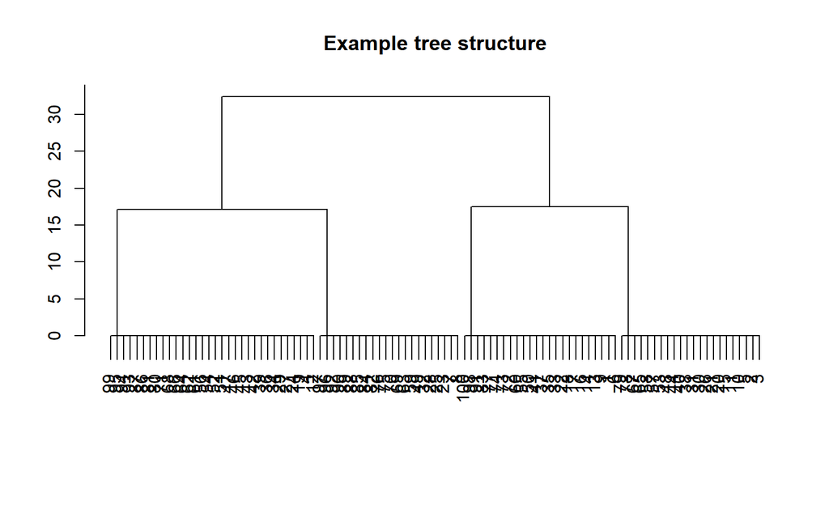

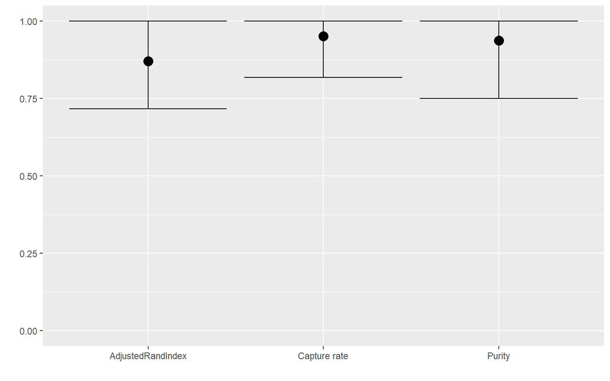

```r
res=DENDRO.simulation(n=100,ref=ref,k=4,subtype=1)
```

```r
res
```

```
#>        AdjustedRandIndex Capture rate    Purity Observation probability
#> CI_low         0.7173185    0.8181818 0.7500000                      NA
#> Mean           0.8701641    0.9520010 0.9370848                       1
#> CI_up          1.0000000    1.0000000 1.0000000                      NA
```

Result shows the example tree structure as well as statistics with 95% Confidence Interval (CI).

### 3.4.2 Example II

In the 2nd example, we want to specify the similar tree but with customized cell proportion and mutation loads. We want the four clusters have cell proportion 0.2, 0.2, 0.2 and 0.4, i.e. we want one major subclone. In our code we need to specify this by parameter `kprob`. Also, we want our mutation load unequally distributed with branch 4 (cluster 4 specific) having more mutations `lprob=c(0.15,0.15,0.15,0.25,0.15,0.15)`.

```
#> There are total  4  clades in our simulation
```

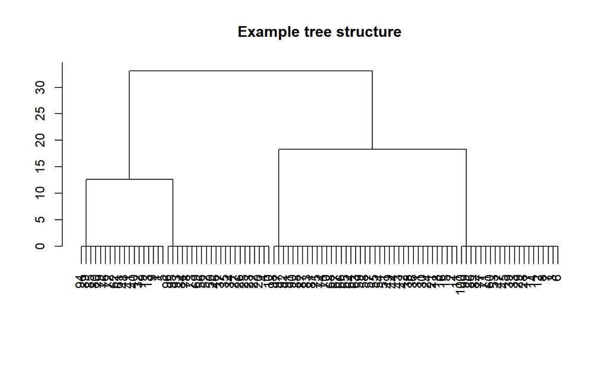

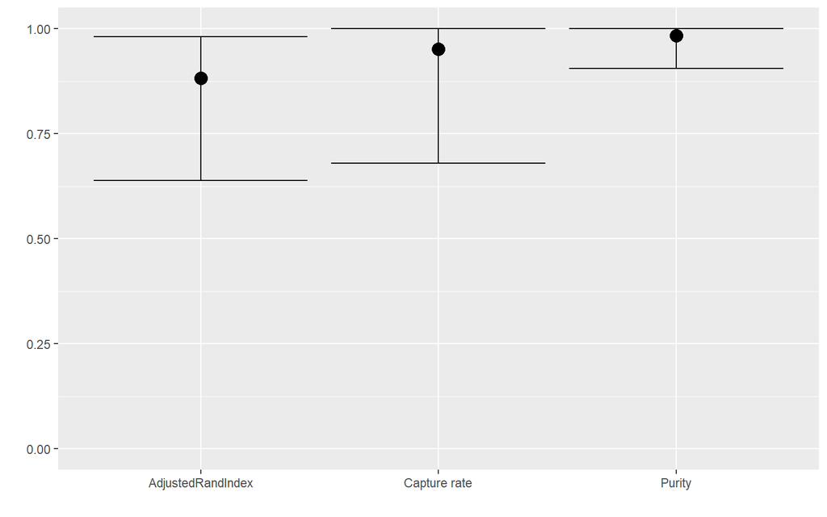

```r
res=DENDRO.simulation(kprob=c(0.2,0.2,0.2,0.4),lprob=c(0.15,0.15,0.15,0.25,0.15,0.15),n=100,ref=ref,k=4,subtype=1)
```

```r
res
```

```
#>        AdjustedRandIndex Capture rate    Purity Observation probability
#> CI_low         0.6393633    0.6800000 0.9056604                      NA
#> Mean           0.8819690    0.9511894 0.9830158                       1
#> CI_up          0.9815705    1.0000000 1.0000000                      NA
```

Example tree shows consistency with our input.

### 3.4.3 Example III

One important reason for user to use this tool is that it can estimate the cluster accuracy given different sequencing depth. In the original Deng et al. paper (Deng et al. 2014), they collect around 10,000,000 50bp-reads per cell in mice, resulting 46 mapped reads for each mutation site, which is super high depth (Figure 4).

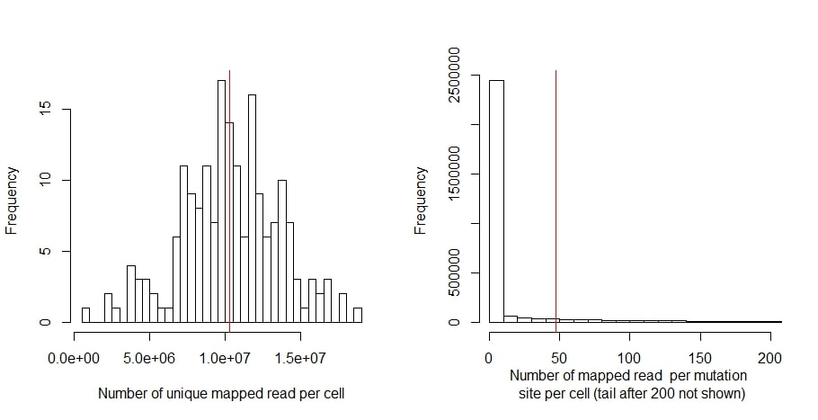

**Figure 4**. scRNA-seq library statistics for Deng et al. (Deng et al. 2014). Modified from [original paper](http://science.sciencemag.org/content/sci/suppl/2014/01/09/343.6167.193.DC1/Deng-SM.pdf).

In real life, usually 1,000,000 reads per cell is pretty good depth. Proportionally, there are around 4.5 mapped reads per mutation site. Let’s change the read depth parameter `RD` and see how well DENDRO performs.

```
#> There are total  4  clades in our simulation
```

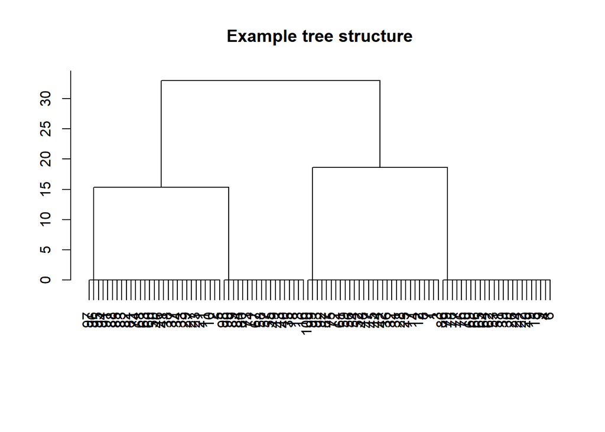

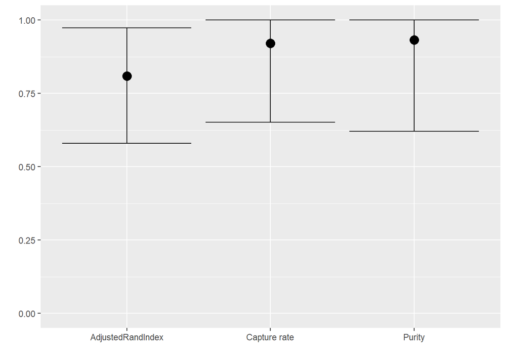

```r
res=DENDRO.simulation(RD=4.5,n=100,ref=ref,k=4,subtype=1)
```

```r
res
```

```
#>        AdjustedRandIndex Capture rate    Purity Observation probability
#> CI_low         0.5795291    0.6521739 0.6206897                      NA
#> Mean           0.8090934    0.9205561 0.9324983                       1
#> CI_up          0.9730729    1.0000000 1.0000000                      NA
```

Feel free to play with different parameters. The detailed function document can be found by typing `??DENDRO.simulation` in R.

# 5. References

Deng, Qiaolin, Daniel Ramsköld, Björn Reinius, and Rickard Sandberg. 2014. “Single-Cell Rna-Seq Reveals Dynamic, Random Monoallelic Gene Expression in Mammalian Cells.” *Science* 343 (6167). American Association for the Advancement of Science: 193–96. doi:10.1126/science.1245316.